# Ethogram Data Collection 2 - Outcome (Success, Fail)

Marinara Marcato

# 1 Introduction

This document shows the data analysis carried out to investigate the association between ethogram scores filled out by two trainers and the dog’s training outcome. Statistical methods will be used to test the hypothesis that there is a relationship between ethogram scores at dc2 and training outcome (Success, Fail).

# 2 Data Exploration

The dataset comprised of the following types and number of variables. The original ethogram items contained ordinal and categorical variables. The score variables were numerical derived from the original ethogram items.

```
##
## categorical    comments        info     ordinal       score        time
##          17          16          17          53          42          25
##      unused
##          11
```

```
##  [1] "Douglas" "Dugg"    "Earl"    "Ebbi"    "Eddie"   "Edrick"  "Effie"
##  [8] "Eldin"   "Elf"     "Eliza"   "Emmy"    "Evie"    "Fargo"   "Fawn"
## [15] "Flora"   "Gav"     "Goober"  "Gretel"  "Harmony" "Harry"   "Harvey"
## [22] "Hayley"  "Herbie"  "Idris"   "Illana"  "Irrie"   "Jane"    "Jazzi"
## [29] "Jessie"  "Jira"    "Jojo"    "Josie"   "Joy"     "July"    "Junior"
## [36] "Kacie"   "Kain"    "Kaiser"  "Kali"    "Katie"   "Kelvin"  "Kirby"
## [43] "Meeko"   "Meg"     "Milo"    "Minnie"  "Rebecca" "Rita"    "Tim"
## [50] "Tosh"    "Toto"    "Vaughan" "Verona"  "Yani"    "Yorkie"  "Zac"
## [57] "Zander"  "Zeb"     "Zita"    "Zodiac"
```

All ordinal (N = 53) and categorical (N = 17) variables from the original ethogram items, score (N = 42) variables derived from the original ethogram items and demographical variables (N = 2) - namely, Sex and Breed - will be analysed.

## 2.1 Demographics

Overview of the dogs participating in the data collection. Inclusion criteria: only Labrador Retrievers (LR) and Labrador Retrievers crossed with Golden Retrievers (LRxGR) were kept for data analysis.

```
## Original dataset (dogs, variables):  60 133
```

```
##
##    GR    LR   LRx LRxGR
##     1    24    12    23
```

```
##
##    LR LRxGR
##    24    35
```

```
## Final dataset (dogs, variables):  59 133
```

```
##
## Success    Fail
##      49      10
```

```
##
##   Success      Fail
## 0.8305085 0.1694915
```

```
##
##  F  M
## 31 28
```

Calculate descriptive statistics for age at arrival at the training centre for formal training. Calculate descriptive statistics for age at assessment when the dogs performed the behaviour test at data collection 1, which should be around week 3 of formal training.

```
## Age at Arrival: Mean NA Standard Deviation NA Minimum: NA Maximum: NA
```

```
## Age at Assessment: Mean NA Standard Deviation NA Minimum: NA Maximum: NA
```

Calculate statistics of duration of training for the dogs that were withdrawn from training. Performing this behaviour test at the beginning on the training (Week 3) would allow assistance dog training organisations to understand which dog are more suitable and allow them to make informed decisions when analysing which dogs to keep for training considering the results of this objective assessment.

```
## [1] "Duration of Training in weeks"
```

```
##     Duration
##  Min.   :10.43
##  1st Qu.:14.21
##  Median :16.29
##  Mean   :17.29
##  3rd Qu.:16.82
##  Max.   :29.57
```

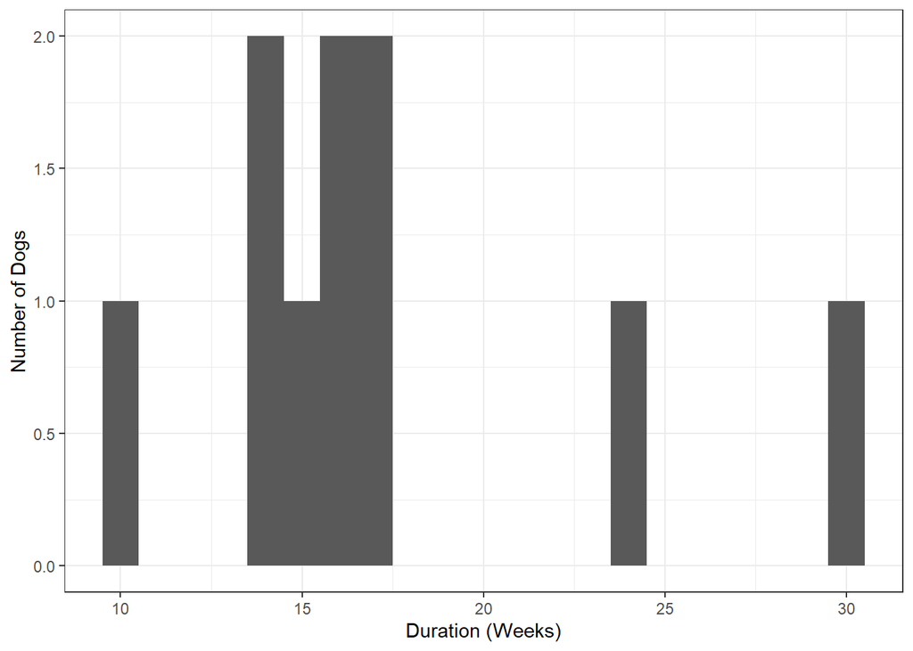

## 2.2 Descriptive Statistics

```
## dataframe saved to  3_analysis/dc2-test/descriptive-statistics-numerical.csv
```

```
##                                                                  No Yes NA.s
## Body.check.General..Mouths.                                      59  59    0
## Body.check.General..Licks.                                       56   3    0
## Tea.Towel.First.Response..Indifferent.                           51   8    0
## Tea.Towel.First.Response..Change.from.Neutral.                    9  50    0
## Tea.Towel.First.Response..Turns.head.                            13  46    0
## Tea.Towel.First.Response..Attempts.to.Removes.towel.by.moving.   34  25    0
## Tea.Towel.First.Response..Attempts.to.Removes.towel.with.mouth.  32  27    0
## Tea.Towel.First.Response..Plays.                                 51   8    0
## Tea.Towel.Second.Response..Indifferent.                          37  22    0
## Tea.Towel.Second.Response..Turns.head.                           29  30    0
## Tea.Towel.Second.Response..Change.from.Neutral.                  21  38    0
## Tea.Towel.Second.Response..Attempts.to.Removes.towel.by.moving.  40  19    0
## Tea.Towel.Second.Response..Attempts.to.Removes.towel.with.mouth. 39  20    0
## Tea.Towel.Second.Response..Plays.                                52   7    0
## Crate.Urinating                                                  59  59    0
## Isolation.Urinating                                              58   1    0
```

```
## dataframe saved to  3_analysis/dc2-test/descriptive-statistics-ordinal.csv
```

```
## dataframe saved to  3_analysis/dc2-test/kong-lateralisation.csv
```

## 2.3 Validity

Categorical with p<0.25: 2 out of 17 ethogram items, 0 out of 2 demographics variables (Sex and Breed).

```
## Categorical variable with 4 factors: Both Left None Righ
```

```
## $Kong.Interaction.Lateralisation
##
## Call:
## glm(formula = Outcome ~ x, family = binomial(link = logit), data = dc_cat,
##     na.action = na.exclude)
##
## Deviance Residuals:
##     Min       1Q   Median       3Q      Max
## -0.9005  -0.5168  -0.4717  -0.4366   2.1899
##
## Coefficients:
##             Estimate Std. Error z value Pr(>|z|)
## (Intercept)  -0.6931     0.6124  -1.132    0.258
## xLeft        -1.2528     0.9728  -1.288    0.198
## xNone        -1.4469     0.9663  -1.497    0.134
## xRigh        -1.6094     1.2143  -1.325    0.185
##
## (Dispersion parameter for binomial family taken to be 1)
##
##     Null deviance: 50.063  on 57  degrees of freedom
## Residual deviance: 46.822  on 54  degrees of freedom
##   (1 observation deleted due to missingness)
## AIC: 54.822
##
## Number of Fisher Scoring iterations: 4
```

Positive estimates increase the probability of failure, while negative estimates decrease the probability of failure. Save results from univariate analysis.

```
## dataframe saved to  3_analysis/dc2-test/univariate-logistic regression.csv.csv
```

```
## dataframe saved to  3_analysis/dc2-test/significant-variables-25.csv.csv
```

## 2.4 Feature Selection

Metholodogy adapted from Hosmer2013, pg 107 (GLOW study example).

### 2.4.1 Step 1: Univariate logistic regression model results.

Features which achieved P < 0.25 were selected for consideration to be included in the reduced feature set. Subsequentely, related variables were removed considering two cases: - Two scores: when both the mean and product scores were selected, the score with the highest p-value was removed. - Score and original items: when both the original item and the score derived from it were selected, the one with the highest p-value was removed.

```
##                                                p_value_1
## Familiarisation.Response..Exploration.         0.2474000
## S.Kong.Response_mean                           0.2437000
## S.Distractions.First.Response_mean             0.2432000
## Familiarisation.Response..Waiting.             0.2279000
## Petting.Responsiveness.After                   0.2239000
## Crate.Behaviours..Whining.                     0.2175000
## Walking.Initiative                             0.2096000
## S.Sensitivity_mean                             0.2066000
## S.Crate.Handler_prod                           0.2051000
## Tea.Towel.Second.Response..Turns.head.         0.1941834
## Distractions.Second.Response..Car.             0.1899000
## S.Crate.Handler_mean                           0.1687000
## Crate.Behaviours..Actively.Seeking.Attention.  0.1525000
## Crate.Behaviours..Sniffing.Exploring..         0.1399000
## S.Familiarisation.Handler_prod                 0.1136000
## Kong.Interaction.Back                          0.1066000
## S.Kong.Response_prod                           0.1028000
## S.Walking.Distractions.Pull_prod               0.0871000
## S.Isolation.Handler_mean                       0.0837000
## Body.check.Table                               0.0751000
## Familiarisation.Response..Oriented.to.Handler. 0.0705000
## S.Familiarisation.Handler_mean                 0.0640000
## Isolation.Response..Exploration.               0.0448000
## Kong.Return.Handler                            0.0399000
## S.Walking.Distractions.Pull_mean               0.0322000
## S.Isolation.Stimulus                           0.0316000
## Walking.Pull.on.leash                          0.0294000
## Isolation.Response..Time.oriented.             0.0286000
## S.Walking.Pull_prod                            0.0255000
## S.Walking.Pull_mean                            0.0210000
## Walking.Pull.strength                          0.0209000
## Distractions.First.Response..Car.              0.0189000
## Kong.Interaction.Response.to.stimulus          0.0145000
```

```
##  [1] "Familiarisation.Response..Oriented.to.Handler."
##  [2] "Familiarisation.Response..Exploration."
##  [3] "Familiarisation.Response..Waiting."
##  [4] "Walking.Pull.on.leash"
##  [5] "Walking.Pull.strength"
##  [6] "Walking.Initiative"
##  [7] "Body.check.Table"
##  [8] "Distractions.First.Response..Car."
##  [9] "Distractions.Second.Response..Car."
## [10] "Kong.Interaction.Response.to.stimulus"
## [11] "Kong.Interaction.Back"
## [12] "Kong.Return.Handler"
## [13] "Crate.Behaviours..Sniffing.Exploring.."
## [14] "Crate.Behaviours..Actively.Seeking.Attention."
## [15] "Crate.Behaviours..Whining."
```

[output cut: 20 more lines]

```
##  [1] "Familiarisation.Response..Exploration."
##  [2] "Body.check.Table"
##  [3] "Distractions.First.Response..Car."
##  [4] "Petting.Responsiveness.After"
##  [5] "Isolation.Response..Time.oriented."
##  [6] "S.Walking.Pull_mean"
##  [7] "S.Familiarisation.Handler_mean"
##  [8] "S.Kong.Response_prod"
##  [9] "S.Isolation.Stimulus"
## [10] "Outcome"
```

```
##                                        p_value_1
## Familiarisation.Response..Exploration.    0.2474
## Petting.Responsiveness.After              0.2239
## S.Kong.Response_prod                      0.1028
## Body.check.Table                          0.0751
## S.Familiarisation.Handler_mean            0.0640
## S.Isolation.Stimulus                      0.0316
## Isolation.Response..Time.oriented.        0.0286
## S.Walking.Pull_mean                       0.0210
## Distractions.First.Response..Car.         0.0189
```

### 2.4.2 Step 2: Correlation

```
## [1] "S.Familiarisation.Handler_mean" "S.Isolation.Stimulus"
```

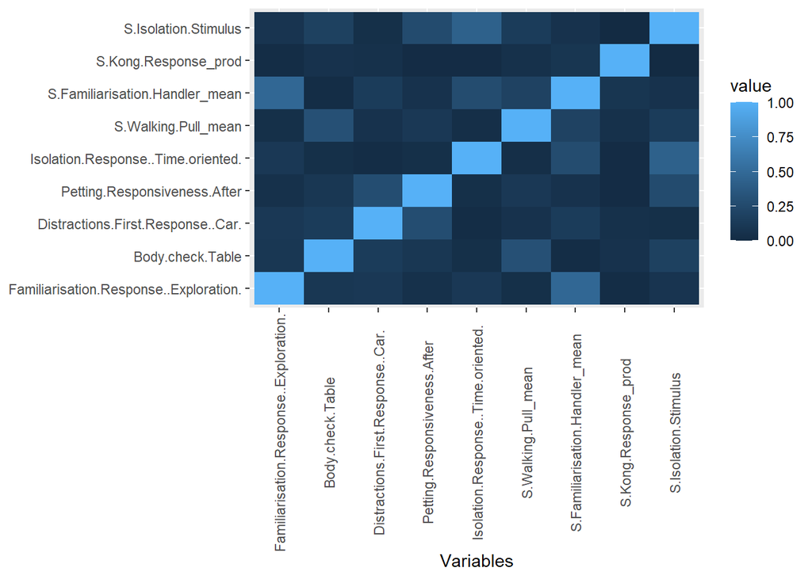

```
## [1] "Familiarisation.Response..Exploration."
## [2] "Body.check.Table"
## [3] "Distractions.First.Response..Car."
## [4] "Petting.Responsiveness.After"
## [5] "Isolation.Response..Time.oriented."
## [6] "S.Walking.Pull_mean"
## [7] "S.Kong.Response_prod"
## [8] "Outcome"
```

## 2.5 Missing Data

dc2, missing values per column and per row. Very few data are missing considering the original items selected.

```
## Familiarisation.Response..Exploration.                       Body.check.Table
##                                      1                                      0
##      Distractions.First.Response..Car.           Petting.Responsiveness.After
##                                      0                                      1
##     Isolation.Response..Time.oriented.                    S.Walking.Pull_mean
##                                      0                                      0
##                   S.Kong.Response_prod                                Outcome
##                                      0                                      0
```

```
## dc_row_nas
##  0  1
## 57  2
```

## 2.6 Visualization

```
## Plot these features manually:
```

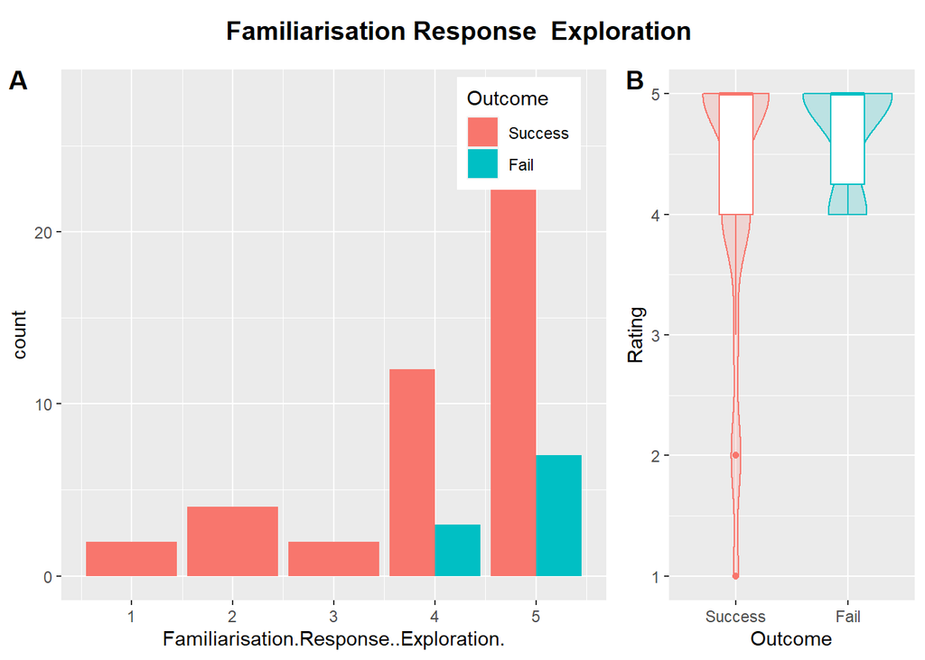

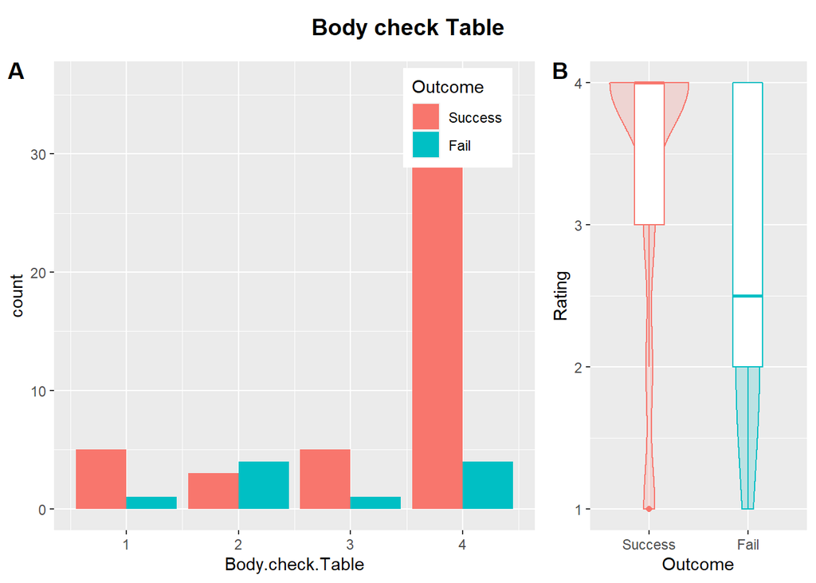

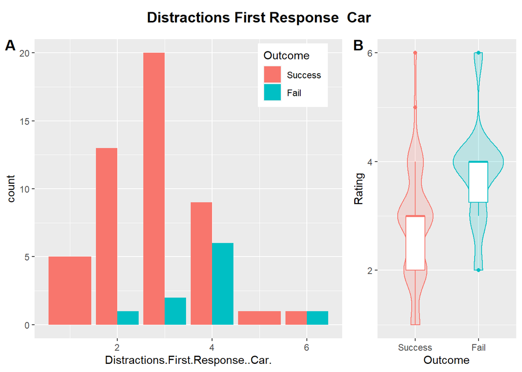

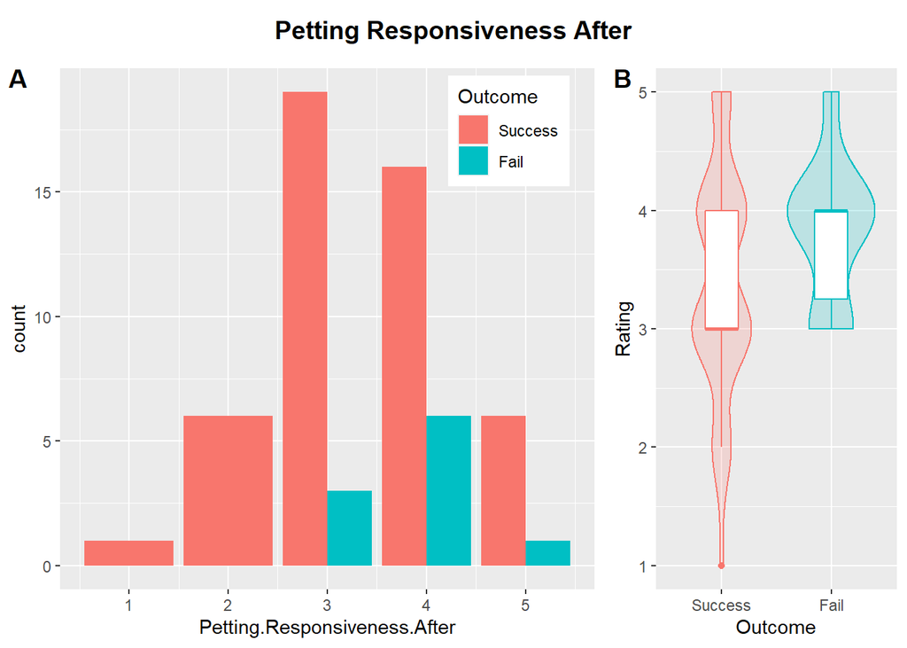

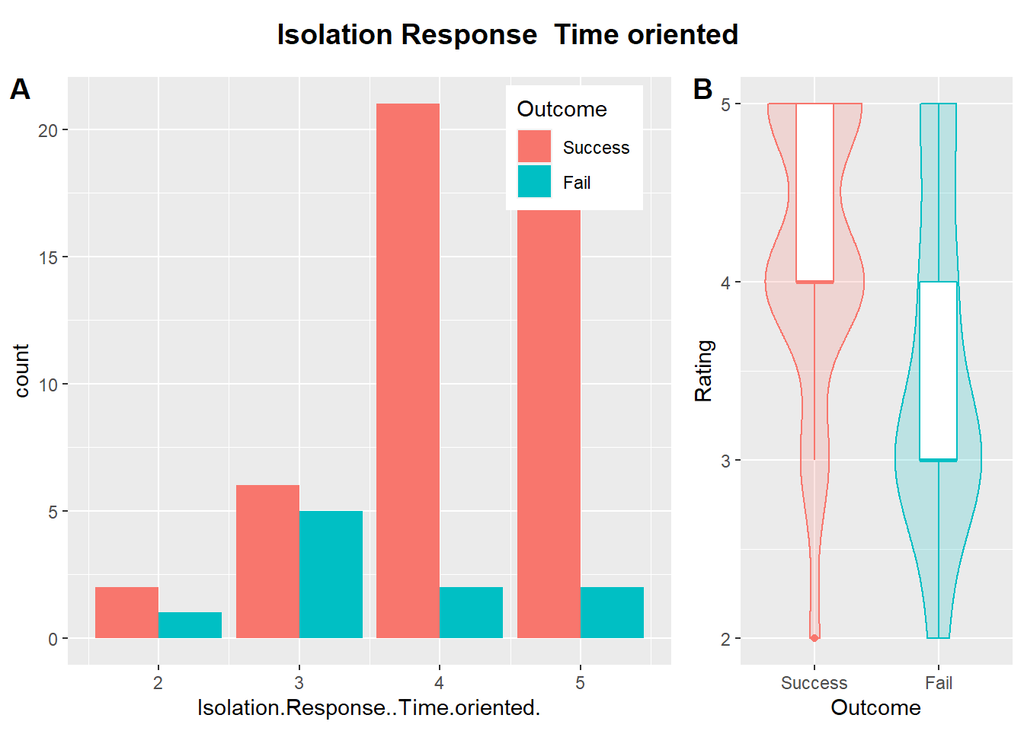

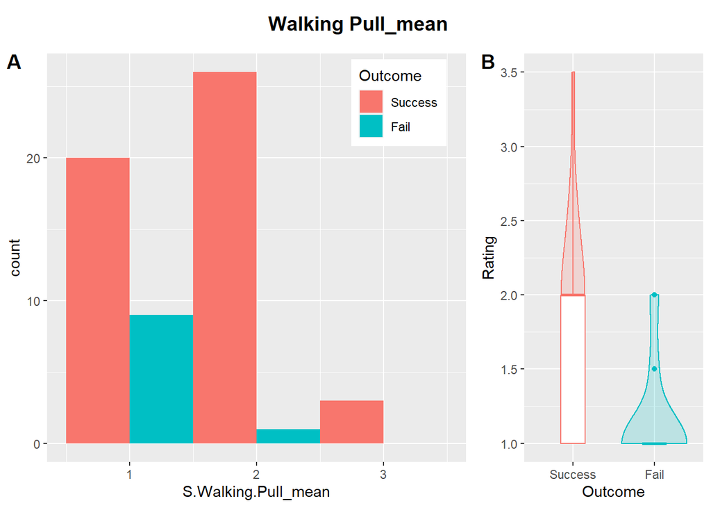

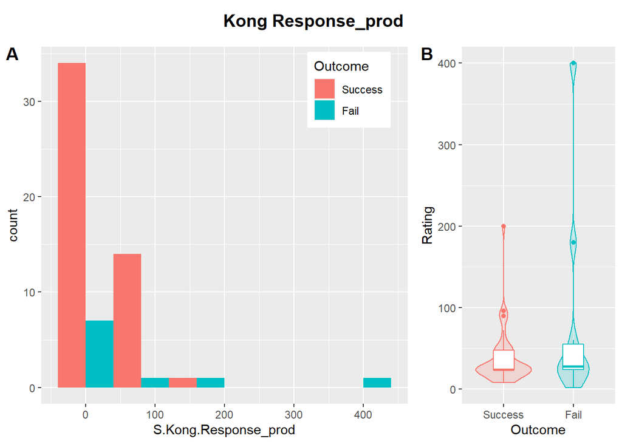

# 3 Multivariate Model

Preprocessing: Normalization + Imputation Recursive Feature Elimination (RFE) + Multivariate Logistic Regression (LR)

```
## [1] "Familiarisation.Response..Exploration."
## [2] "Body.check.Table"
## [3] "Distractions.First.Response..Car."
## [4] "Petting.Responsiveness.After"
## [5] "Isolation.Response..Time.oriented."
## [6] "S.Walking.Pull_mean"
## [7] "S.Kong.Response_prod"
## [8] "Outcome"
```

```
## predicting second class: Fail Success
```

```
##
## Recursive feature selection
##
## Outer resampling method: Cross-Validated (59 fold)
##
## Resampling performance over subset size:
##
##  Variables AUC Precision Recall   F AUCSD PrecisionSD RecallSD FSD
##          1 NaN    0.0000    0.0 NaN    NA      0.0000   0.0000  NA
##          2 NaN    0.5455    0.6   1    NA      0.5222   0.5164   0
##          3 NaN    0.7500    0.6   1    NA      0.4629   0.5164   0
##          4 NaN    0.6667    0.6   1    NA      0.5000   0.5164   0
##          5 NaN    0.7000    0.7   1    NA      0.4830   0.4830   0
##          6 NaN    0.7778    0.7   1    NA      0.4410   0.4830   0
##          7 NaN    0.7778    0.7   1    NA      0.4410   0.4830   0
##  Num_Resamples Selected
##             59
##             59
##             59
##             59
##             59
##             59        *
##             59
##
## The top 5 variables (out of 6):
##    Distractions.First.Response..Car., S.Walking.Pull_mean, Isolation.Response..Time.oriented., Familiarisation.Response..Exploration., S.Kong.Response_prod
```

```
##
## Call:
## glm(formula = Class ~ ., family = "binomial", data = tmp)
##
## Deviance Residuals:
##      Min        1Q    Median        3Q       Max
## -2.75043   0.00944   0.09149   0.29796   1.19060
##
## Coefficients:
##                                        Estimate Std. Error z value Pr(>|z|)
## (Intercept)                              3.8314     1.1330   3.382 0.000721 ***
## Distractions.First.Response..Car.       -2.2053     0.8783  -2.511 0.012042 *
## S.Walking.Pull_mean                      2.5489     1.0262   2.484 0.012997 *
## Isolation.Response..Time.oriented.       1.3201     0.6606   1.998 0.045700 *
## Familiarisation.Response..Exploration.  -1.4939     1.0373  -1.440 0.149812
## S.Kong.Response_prod                    -0.4574     0.6787  -0.674 0.500376
## Body.check.Table                         0.1876     0.4997   0.375 0.707298
## ---
## Signif. codes:  0 '***' 0.001 '**' 0.01 '*' 0.05 '.' 0.1 ' ' 1
##
## (Dispersion parameter for binomial family taken to be 1)
##
##     Null deviance: 53.699  on 58  degrees of freedom
## Residual deviance: 21.465  on 52  degrees of freedom
## AIC: 35.465
##
## Number of Fisher Scoring iterations: 7
```

Model fitness with deviance analysis.

```
##
## deviance difference:  32.23478
```

```
##
## df difference:  6
```

```
##
## level of significance:  1.471065e-05
```

```
##
## the model is a good fit:  TRUE
```

Performance metrics ROC and PR curves.

```
## Confusion Matrix and Statistics
##
##           Reference
## Prediction Fail Success
##    Fail       7       2
##    Success    3      47
##
##                Accuracy : 0.9153
##                  95% CI : (0.8132, 0.9719)
##     No Information Rate : 0.8305
##     P-Value [Acc > NIR] : 0.05094
##
##                   Kappa : 0.6865
##
##  Mcnemar's Test P-Value : 1.00000
##
##             Sensitivity : 0.7000
##             Specificity : 0.9592
##          Pos Pred Value : 0.7778
##          Neg Pred Value : 0.9400
##              Prevalence : 0.1695
##          Detection Rate : 0.1186
##    Detection Prevalence : 0.1525
##       Balanced Accuracy : 0.8296
##
##        'Positive' Class : Fail
##
```

```
##
##   ROC curve
##
##     Area under curve:
##      0.8326531
##
##     Curve for scores from  3.540616e-07  to  0.9917694
##     ( can be plotted with plot(x) )
```

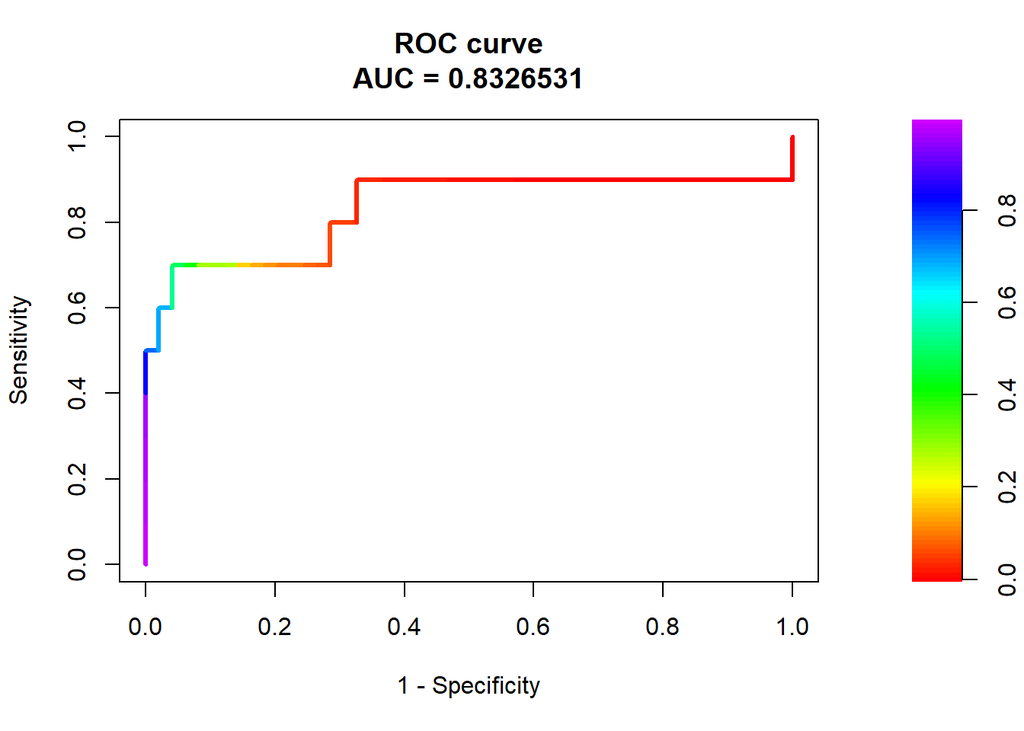

```
## Confusion Matrix and Statistics
##
##           Reference
## Prediction Fail Success
##    Fail       7       2
##    Success    3      47
##
##                Accuracy : 0.9153
##                  95% CI : (0.8132, 0.9719)
##     No Information Rate : 0.8305
##     P-Value [Acc > NIR] : 0.05094
##
##                   Kappa : 0.6865
##
##  Mcnemar's Test P-Value : 1.00000
##
##               Precision : 0.7778
##                  Recall : 0.7000
##                      F1 : 0.7368
##              Prevalence : 0.1695
##          Detection Rate : 0.1186
##    Detection Prevalence : 0.1525
##       Balanced Accuracy : 0.8296
##
##        'Positive' Class : Fail
##
```

```
##
##   Precision-recall curve
##
##     Area under curve (Integral):
##      0.7468224
##
##     Area under curve (Davis & Goadrich):
##      0.746661
##
##     Curve for scores from  3.540616e-07  to  0.9917694
##     ( can be plotted with plot(x) )
```

Plot the logit functions

```
## [1] "Probability predicted by the LR using PRQ data vs true Outcome"
```

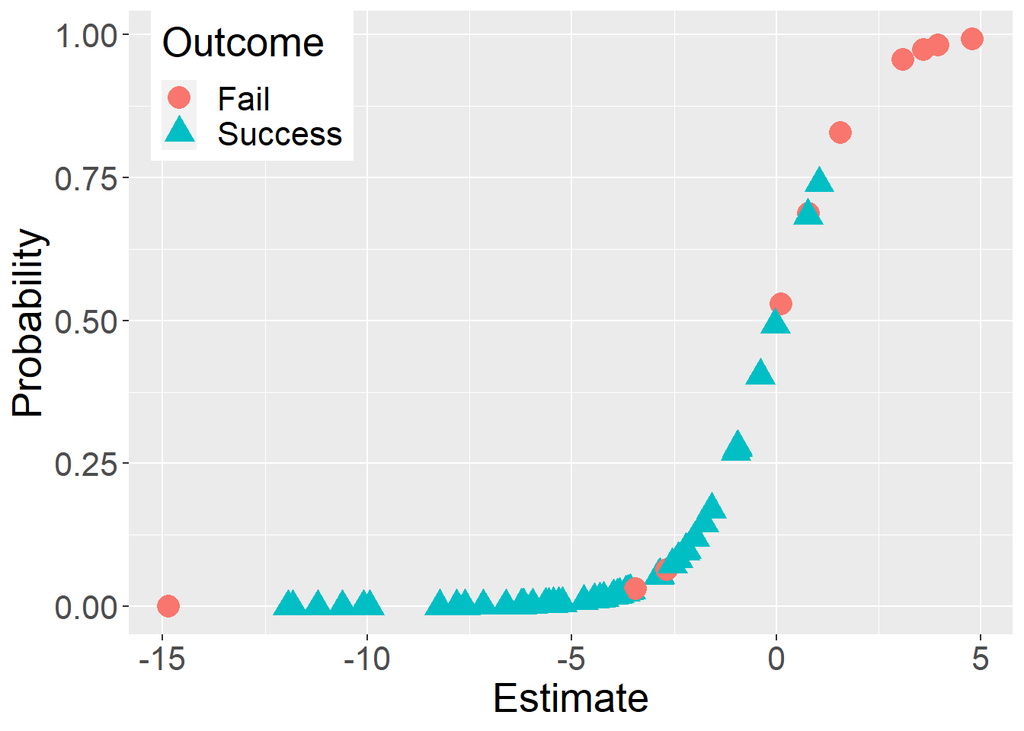

```
## [1] "Probability predicted by the LR using PRQ data vs true Status"
```

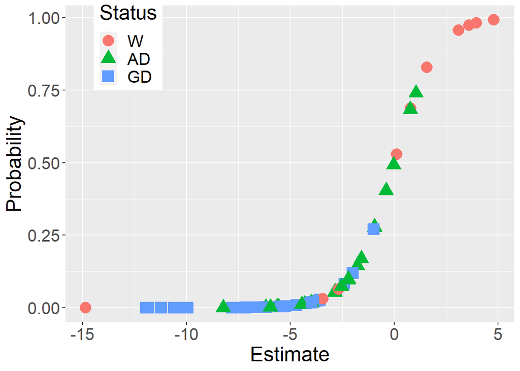

```
## [1] "Estimate and Probabilities per training outcome status"
```

```
## # A tibble: 3 × 2
##   Status   Mean
##   <fct>   <dbl>
## 1 W      -0.306
## 2 AD     -3.05
## 3 GD     -6.14
```

```
## # A tibble: 3 × 2
##   Status   Mean
##   <fct>   <dbl>
## 1 W      0.604
## 2 AD     0.165
## 3 GD     0.0244
```

Check the dogs that were false positives or false negatives

```
##                  Index Probability
## predictions.1120    18   0.6832504
## predictions.1131    29   0.7400145
```

```
## [1] Gav  Jane
## 60 Levels: Douglas Dugg Earl Ebbi Eddie Edrick Effie Eldin Elf Eliza ... Zodiac
```

```
##                  Index  Probability
## predictions.1145    43 3.540616e-07
## predictions.1143    41 3.095109e-02
## predictions.1132    30 6.386194e-02
```

```
## [1] Meg    Zander Hayley
## 60 Levels: Douglas Dugg Earl Ebbi Eddie Edrick Effie Eldin Elf Eliza ... Zodiac
```

## 3.1 Interpretation

```
## [1] "Results from the model created"
```

```
##                                          Estimate Std. Error    z value
## (Intercept)                             3.8314045  1.1330214  3.3815817
## Distractions.First.Response..Car.      -2.2053154  0.8782935 -2.5109094
## S.Walking.Pull_mean                     2.5489099  1.0261948  2.4838461
## Isolation.Response..Time.oriented.      1.3200754  0.6606485  1.9981509
## Familiarisation.Response..Exploration. -1.4939476  1.0373238 -1.4401941
## S.Kong.Response_prod                   -0.4573744  0.6786999 -0.6738979
## Body.check.Table                        0.1876350  0.4997100  0.3754878
##                                           Pr(>|z|)         OR      2.5 %
## (Intercept)                            0.000720698 46.1272787 8.35564008
## Distractions.First.Response..Car.      0.012042060  0.1102158 0.01139519
## S.Walking.Pull_mean                    0.012997198 12.7931505 2.67168428
## Isolation.Response..Time.oriented.     0.045700301  3.7437035 1.21102019
## Familiarisation.Response..Exploration. 0.149812481  0.2244847 0.01246289
## S.Kong.Response_prod                   0.500376233  0.6329433 0.12971504
## Body.check.Table                       0.707297710  1.2063931 0.39396922
##                                             97.5 %
## (Intercept)                            926.6073062
## Distractions.First.Response..Car.        0.4230057
## S.Walking.Pull_mean                    198.0321587
## Isolation.Response..Time.oriented.      19.0385276
## Familiarisation.Response..Exploration.   0.9770808
## S.Kong.Response_prod                     1.7254685
## Body.check.Table                         3.1652194
```

```
## dataframe saved to  3_analysis/dc2-test/rfe-lr.csv
```

# 4 Conclusion